# Test Miami-Dade SIR Report

Anshul Saxena and Gabriel Odom

2020-04-10

## Overview

Given daily updates from Miami-Dade EMS, we would like to re-assess the models that fit the COVID-19 pandemic best for this county. However, note that these estimates depend on a wide variety of things being correct: the data we have, the models we choose, the tuning parameters for these models, and the assumptions we make for these models.

## Setup

We need to load some R packages before we can perform our computing.

```r
library(reticulate)
library(tidyverse)
```

This code is hosted at https://github.com/Rwilli5/SFCHIME. The shell script to install the packages we need is in `src/install_python_packages_20200403.sh`. This creates a conda environment called `env_sflCHIME` and activates it. *NOTE: At current, I have been unable to run these commands on Windows.*

On Mac, I have a Conda environment created for this project. In the terminal, I type `which python` and it tells me

```
/Users/gabrielodom/anaconda3/envs/env_sflCHIME/bin/python
```

If, during your replication of this work, it says

```
/usr/bin/python
```

(or some other place), then something is wrong.

I specifically want this python environment mentioned above, so I use the `use_python()` function to “point” the `reticulate` package to the particular environment that we installed with Anaconda, replete with the version of Python we selected and all associated libraries. (**NOTE**: this line must be executed before any other `reticulate` functions or Python calls, otherwise it will have no effect.)

```r
use_python(
    "/Users/gabrielodom/anaconda3/envs/env_sflCHIME/bin/python",
    required = TRUE
)
```

Now that we have a working install of Python with the necessary environment, we then load some Python libraries.

```python
from functools import reduce
from typing import Tuple, Dict, Any
import pandas as pd
import streamlit as st
import numpy as np
import altair as alt
```

## Parameters

### Hospital Parameters

```python
# Regional Population
S_default = 2761581.0

# Hospital Market Share
Penn_market_share = 1.0

# Currently Hospitalised Patients (at current hospital?)
known_cases = 636.0
current_hosp = known_cases
```

We set the population of Miami-Dade to 2761581 and the number of currently-hospitalised patients to 636.

### Spread and Contact Parameters

```python
# First Case Date
first_case = "2020-03-11"

# Doubling Time
doubling_time = 6.0

# Social Distancing (% reduction in social contact)
relative_contact_rate = 0.1
```

### Severity Rates

```python
# Hospitalisation (% of total infections)
hosp_rate = 0.2

# ICU (% of total infections)
icu_rate = (215 / 636) * hosp_rate

# Ventilated (% of total infections)
vent_rate = (166/636) * hosp_rate

# Death (% of total infections)
death_rate = 0.8 * vent_rate + (1 - hosp_rate) * 0.0066
# 0.0066 based on Lancet paper: https://doi.org/10.1016/S1473-3099(20)30243-7
```

### Severity Times

```python
# Infectious Days
recovery_days = 17.0

# # Average hospital length of stay (days)
# hosp_los = 7.0
#
# # Average ICU length of stay (days)
# icu_los = 9.0
#
# # Average length of stay on a ventilator (days)
# vent_los = 5.0
```

## Directly Estimated Parameters

Given the parameters above, we calculate the following disease spread parameters.

### SIR Initial Values

```python
total_infections = current_hosp / Penn_market_share / hosp_rate
print(total_infections)
```

```
## 3180.0
```

```python
Infct = total_infections
Susc, Infct, Recov, Dead = S_default - Infct, Infct, 0.0, 0.0
print(Susc)
```

```
## 2758401.0
```

```python
print(Infct)
```

```
## 3180.0
```

```python
intrinsic_growth_rate = 2 ** (1 / doubling_time) - 1
print(intrinsic_growth_rate)
```

```
## 0.12246204830937302
```

**NOTE**: the total infections and initial infections are equal at $t = 0$.

### SIRD Transition Rates

```python
gamma = 1.0 / recovery_days
# mean recovery rate, gamma, (in 1/days).
print(gamma)
```

```
## 0.058823529411764705
```

```python
beta = (intrinsic_growth_rate + gamma) / Susc * (1.0 - relative_contact_rate)
# Contact rate, beta
# {rate based on doubling time} / {initial Susc}
print(beta)
```

```
## 5.914913022037911e-08
```

```python
mu = death_rate
# Death rate, mu

r_t = beta / gamma * Susc
# Current Reproduction Number
# r_t is r_0 after distancing
print(r_t)
```

```
## 2.7736693391334075
```

```python
r_naught = r_t / (1.0 - relative_contact_rate)
# Initial Reproduction Number
print(r_naught)
```

```
## 3.0818548212593417
```

```python
doubling_time_t = 1.0 / np.log2(beta * Susc - gamma + 1.0)
# Current Doubling Time
# doubling time after distancing
print(doubling_time_t)
```

```
## 6.984415279729236
```

As an aside, if I want to access any of these values in R (for instance, $R_0$), I can call them as `py$r_naught`, which yields 3.0818548.

## Model Specification

We can now specify the SIRD model at outset and over time.

```python
# SIR at Outset
def sird(y, beta, gamma, mu, N):
    S, I, R, D = y
    Sn = (-beta * S * I) + S
    In = (beta * S * I - gamma * I - mu * I) + I
    Rn = gamma * I + R
    Dn = mu * I + D
    if Sn < 0:
        Sn = 0.0
    if In < 0:
        In = 0.0
    if Rn < 0:
        Rn = 0.0
    if Dn < 0:
        Dn = 0.0

    scale = N / (Sn + In + Rn + Dn)
    return Sn * scale, In * scale, Rn * scale, Dn * scale


# Dynamic SIR
def sim_sird(S, I, R, D, beta, gamma, mu, n_days, beta_decay = None):
    N = S + I + R + D
    s, i, r, d = [S], [I], [R], [D]
    for day in range(n_days):
        y = S, I, R, D
        S, I, R, D = sird(y, beta, gamma, mu, N)
        if beta_decay:
            beta = beta * (1 - beta_decay)
        s.append(S)
        i.append(I)
        r.append(R)
        d.append(D)

    s, i, r, d = np.array(s), np.array(i), np.array(r), np.array(d)
    return s, i, r, d
```

```python
n_days = 100
beta_decay = 0.01

s, i, r, d = sim_sird(
  Susc, Infct, Recov, Dead, beta, gamma, mu, n_days, beta_decay = beta_decay
)
```

**ERROR**: `Error in py_call_impl(callable, dots$args, dots$keywords) :` `TypeError: unsupported operand type(s) for +: 'float' and 'type'`  
**SOLUTION**: I can’t have a Python object named `R`.

We now inspect the results of this model

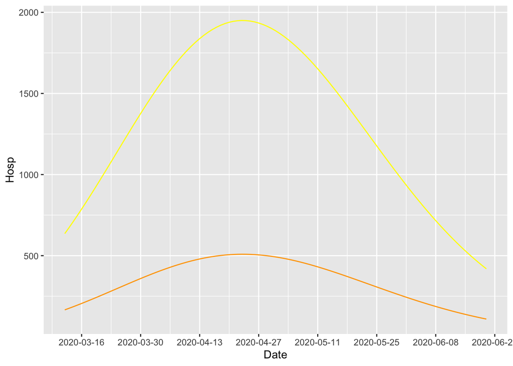

```r
res_df <- tibble(
    days  = seq_len(py$n_days + 1),
    Susc  = py$s,
    Infct = py$i,
    Recov = py$r,
    Dead  = py$d
) %>%
  mutate(
    Hosp = Infct * py$hosp_rate,
    ICU  = Infct * py$icu_rate,
    Vent = Infct * py$vent_rate
  ) %>%
  mutate(
    Date = lubridate::ymd(py$first_case) + days
  )


ggplot(data = res_df) +
  aes(x = Date) +
  # scale_y_log10(breaks = 3 * 10^(0:7)) +
  scale_x_date(date_breaks = "2 weeks") +

  geom_line(aes(y = Hosp), colour = "yellow") +
  geom_line(aes(y = Vent), colour = "orange")
```

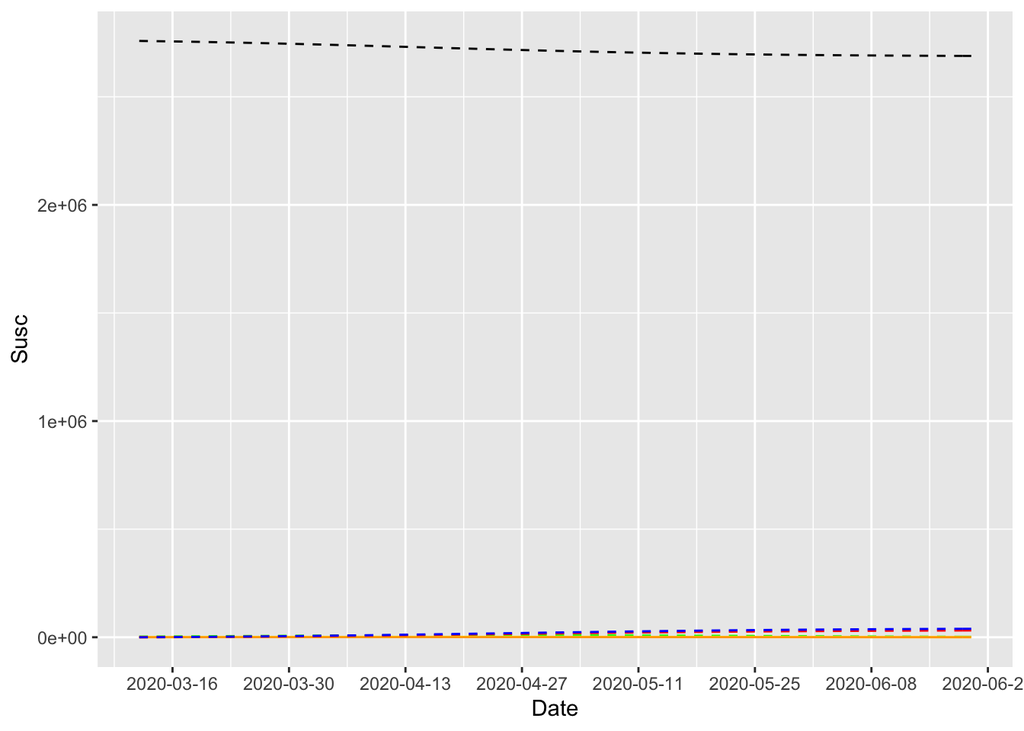

```r
ggplot(data = res_df) +
  aes(x = Date) +
  # scale_y_log10(breaks = 3 * 10^(0:7)) +
  scale_x_date(date_breaks = "2 weeks") +

  geom_line(aes(y = Susc), colour = "black", linetype = "dashed") +

  geom_line(aes(y = Infct), colour = "green", linetype = "dashed") +
  geom_line(aes(y = Hosp), colour = "yellow") +
  geom_line(aes(y = Vent), colour = "orange") +
  geom_line(aes(y = Dead), colour = "red", linetype = "dashed") +

  geom_line(aes(y = Recov), colour = "blue", linetype = "dashed")
```